# AllLife Credit Card Customer Segmentation (Unsupervised Learning)

**Background:** AllLife Bank wants to focus on its credit card customer base in the next financial year. They have been advised by their marketing research team, that the penetration in the market can be improved. Based on this input, the Marketing team proposes to run personalised campaigns to target new customers as well as upsell to existing customers. Another insight from the market research was that the customers perceive the support services of the back poorly. Based on this, the Operations team wants to upgrade the service delivery model, to ensure that customers queries are resolved faster. Head of Marketing and Head of Delivery both decide to reach out to the Data Science team for help.

**Objective:** To identify different segments in the existing customer based on their spending paterns as well as past interaction with the bank.

```python
import warnings
warnings.filterwarnings('ignore')
```

```python
import numpy as np
import pandas as pd
import matplotlib.pyplot as plt
import seaborn as sns
from sklearn.model_selection  import train_test_split
from sklearn.cluster import KMeans

from scipy.stats import zscore
from sklearn.metrics import silhouette_score

%matplotlib inline
%config InlineBackend.figure_format = 'retina'

plt.style.use('ggplot')
```

```python
# importing data
df = pd.read_excel('Credit Card Customer Data.xlsx')
```

## Overview of Data

```python
df.shape
```

```
(660, 7)
```

```python
df.head(10)
```

|  | Sl_No | Customer Key | Avg_Credit_Limit | Total_Credit_Cards | Total_visits_bank | Total_visits_online | Total_calls_made |
| --- | --- | --- | --- | --- | --- | --- | --- |
| 0 | 1 | 87073 | 100000 | 2 | 1 | 1 | 0 |
| 1 | 2 | 38414 | 50000 | 3 | 0 | 10 | 9 |
| 2 | 3 | 17341 | 50000 | 7 | 1 | 3 | 4 |
| 3 | 4 | 40496 | 30000 | 5 | 1 | 1 | 4 |
| 4 | 5 | 47437 | 100000 | 6 | 0 | 12 | 3 |
| 5 | 6 | 58634 | 20000 | 3 | 0 | 1 | 8 |
| 6 | 7 | 48370 | 100000 | 5 | 0 | 11 | 2 |
| 7 | 8 | 37376 | 15000 | 3 | 0 | 1 | 1 |
| 8 | 9 | 82490 | 5000 | 2 | 0 | 2 | 2 |
| 9 | 10 | 44770 | 3000 | 4 | 0 | 1 | 7 |

```python
df.info()
```

```
<class 'pandas.core.frame.DataFrame'>
RangeIndex: 660 entries, 0 to 659
Data columns (total 7 columns):
 #   Column               Non-Null Count  Dtype
---  ------               --------------  -----
 0   Sl_No                660 non-null    int64
 1   Customer Key         660 non-null    int64
 2   Avg_Credit_Limit     660 non-null    int64
 3   Total_Credit_Cards   660 non-null    int64
 4   Total_visits_bank    660 non-null    int64
 5   Total_visits_online  660 non-null    int64
 6   Total_calls_made     660 non-null    int64
dtypes: int64(7)
memory usage: 36.2 KB
```

```python
df.isnull().sum()
```

```
Sl_No                  0
Customer Key           0
Avg_Credit_Limit       0
Total_Credit_Cards     0
Total_visits_bank      0
Total_visits_online    0
Total_calls_made       0
dtype: int64
```

**Insight:** There are no null or missing data values in our dataframe that we need to deal with.

```python
df.nunique()
```

```
Sl_No                  660
Customer Key           655
Avg_Credit_Limit       110
Total_Credit_Cards      10
Total_visits_bank        6
Total_visits_online     16
Total_calls_made        11
dtype: int64
```

```python
duplicated_cus_key = list(df.loc[df.duplicated(keep='first', subset=['Customer Key']) == True]['Customer Key'])
duplicated_cus_key
```

```
[47437, 96929, 37252, 50706, 97935]
```

`above list shows that 5 customer keys are duplicated, wheras the data for each differs, so the information for these customers is not duplicated as a whole which leads us to believe that an error was made when entering the Customer Key. This only affects 10 out of the 660 total records. Given the lack of knowledge on this error, and the small number of records it affects, we will leave these records as they likely represent real customers, and haveing such a small data set makes us hesitant to remove these records`

```python
# Remove SI_No and Customer Key as it is redundant information and not useful for clustering
# df_att = df.iloc[:,2:]
df_att = df.drop(['Sl_No', 'Customer Key'], axis=1)
df_att.head()
```

|  | Avg_Credit_Limit | Total_Credit_Cards | Total_visits_bank | Total_visits_online | Total_calls_made |
| --- | --- | --- | --- | --- | --- |
| 0 | 100000 | 2 | 1 | 1 | 0 |
| 1 | 50000 | 3 | 0 | 10 | 9 |
| 2 | 50000 | 7 | 1 | 3 | 4 |
| 3 | 30000 | 5 | 1 | 1 | 4 |
| 4 | 100000 | 6 | 0 | 12 | 3 |

## Univariate Analysis

```python
df_att.describe()
```

|  | Avg_Credit_Limit | Total_Credit_Cards | Total_visits_bank | Total_visits_online | Total_calls_made |
| --- | --- | --- | --- | --- | --- |
| count | 660.000000 | 660.000000 | 660.000000 | 660.000000 | 660.000000 |
| mean | 34574.242424 | 4.706061 | 2.403030 | 2.606061 | 3.583333 |
| std | 37625.487804 | 2.167835 | 1.631813 | 2.935724 | 2.865317 |
| min | 3000.000000 | 1.000000 | 0.000000 | 0.000000 | 0.000000 |
| 25% | 10000.000000 | 3.000000 | 1.000000 | 1.000000 | 1.000000 |
| 50% | 18000.000000 | 5.000000 | 2.000000 | 2.000000 | 3.000000 |
| 75% | 48000.000000 | 6.000000 | 4.000000 | 4.000000 | 5.000000 |
| max | 200000.000000 | 10.000000 | 5.000000 | 15.000000 | 10.000000 |

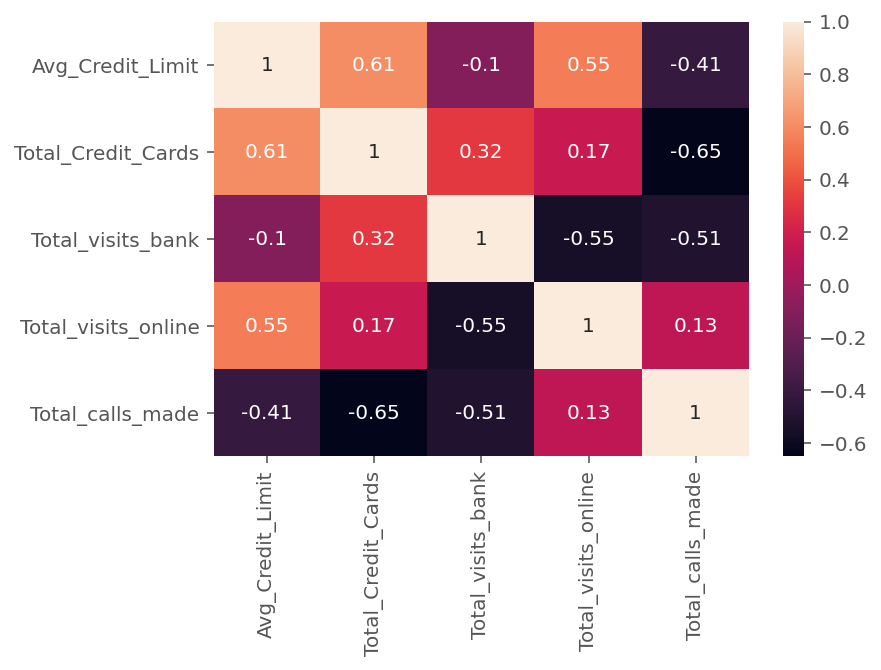

```python
corr = df_att.corr()
sns.heatmap(corr, annot = True)
```

**Insights:** We see AVG_Credit_Limit having a positive correlation with both Total_Credit_Cards and Total_visits_online, while seeing negative correlation between Total_calls_made and Total_Credit_Cards, Total_calls_made and Total_visits_bank, and Total_visits_bank and Total_visits_online

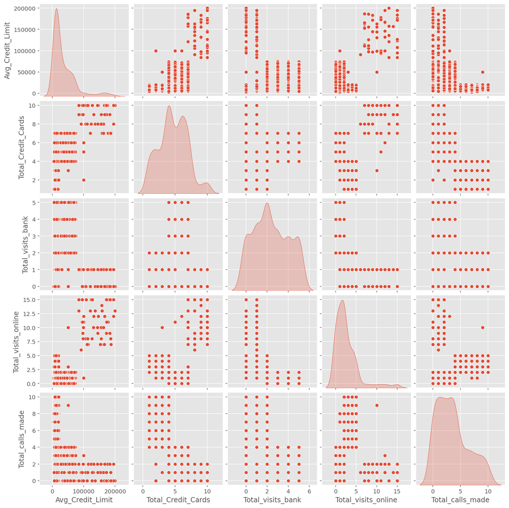

```python
sns.pairplot(df_att, diag_kind='kde');
```

**insights:** From diagonal plots we can see Avg_Credit_Limit has 3 peaks, while Total_visits_online and Total_calls_made seem to show 3-4 peaks, but hard to make them out well. Total_Credit_Cards shows 4 peaks, and Total_visits_bank seems to have 5 peaks. From this, we would expect between 3-5 clusters might make sense for this dataset.

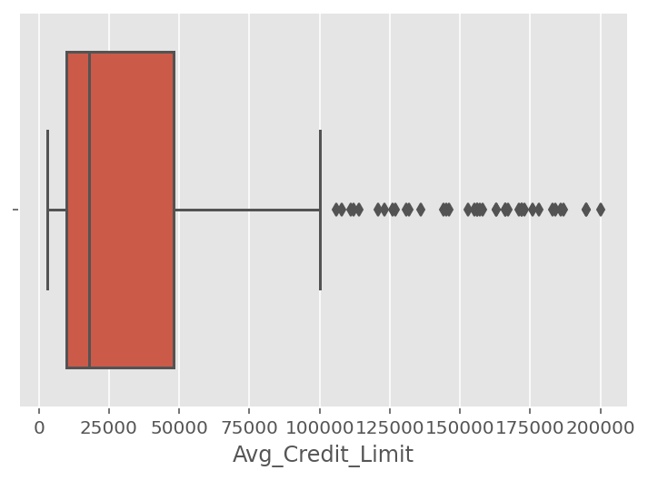

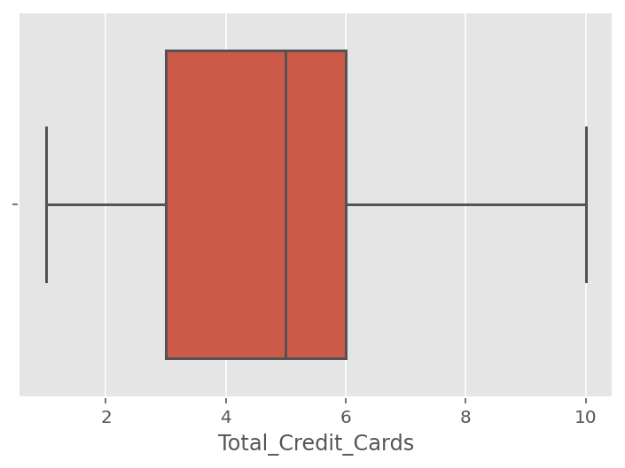

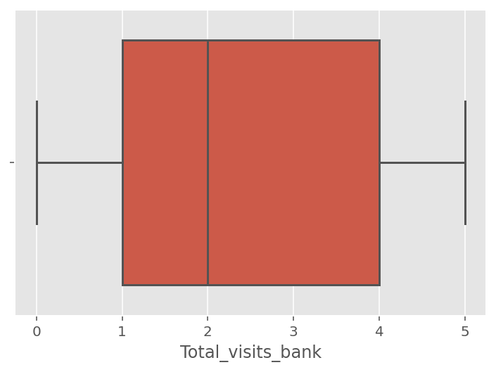

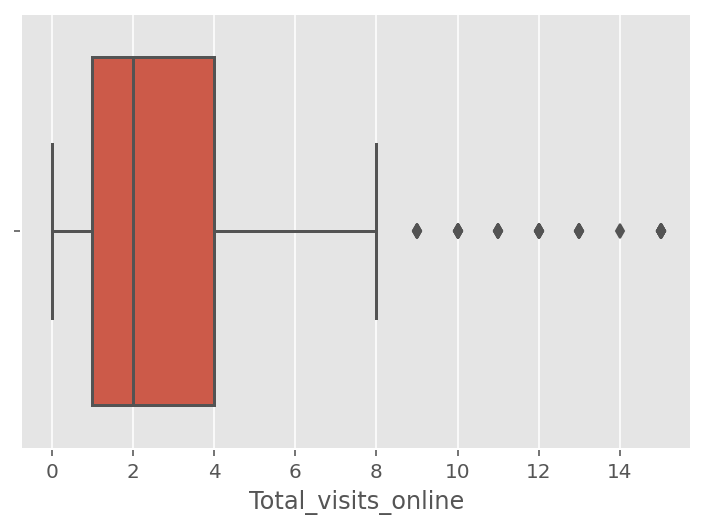

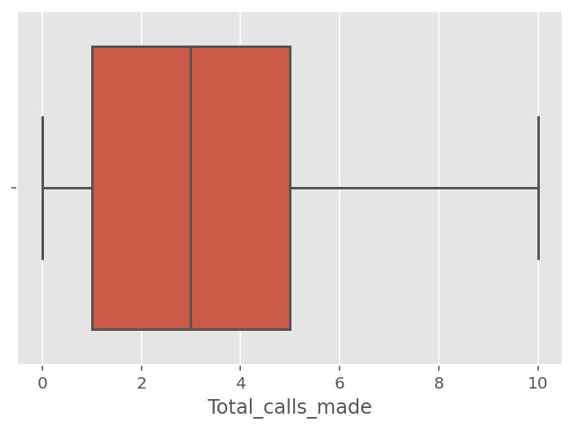

```python
df_col_val = df_att.columns.values
for i in df_col_val:
    sns.boxplot(x = df_att[i])
    plt.show()
```

**Insights:** We see some outliers present in Avg_Credit_limit and Total_visits_online, which may affect the clustering when using Euclidean distance. Although, it's expected to see outliers in Avg_Credit_limit given the nature of banks and their customers. Therefore, for the time bieng, we'll leave these outliers and see how our clustering turns out before removing doing anything more than scaling the data below.

#### Standardize the data

```python
df_scaled = df_att.apply(zscore)
df_scaled.head()
```

|  | Avg_Credit_Limit | Total_Credit_Cards | Total_visits_bank | Total_visits_online | Total_calls_made |
| --- | --- | --- | --- | --- | --- |
| 0 | 1.740187 | -1.249225 | -0.860451 | -0.547490 | -1.251537 |
| 1 | 0.410293 | -0.787585 | -1.473731 | 2.520519 | 1.891859 |
| 2 | 0.410293 | 1.058973 | -0.860451 | 0.134290 | 0.145528 |
| 3 | -0.121665 | 0.135694 | -0.860451 | -0.547490 | 0.145528 |
| 4 | 1.740187 | 0.597334 | -1.473731 | 3.202298 | -0.203739 |

```python
df_scaled.describe()
```

|  | Avg_Credit_Limit | Total_Credit_Cards | Total_visits_bank | Total_visits_online | Total_calls_made |
| --- | --- | --- | --- | --- | --- |
| count | 6.600000e+02 | 6.600000e+02 | 6.600000e+02 | 6.600000e+02 | 6.600000e+02 |
| mean | 8.195465e-16 | -4.006223e-15 | 1.157323e-16 | 1.944572e-16 | -7.112156e-16 |
| std | 1.000758e+00 | 1.000758e+00 | 1.000758e+00 | 1.000758e+00 | 1.000758e+00 |
| min | -8.398081e-01 | -1.710864e+00 | -1.473731e+00 | -8.883795e-01 | -1.251537e+00 |
| 25% | -6.536229e-01 | -7.875852e-01 | -8.604506e-01 | -5.474897e-01 | -9.022711e-01 |
| 50% | -4.408398e-01 | 1.356941e-01 | -2.471705e-01 | -2.065999e-01 | -2.037386e-01 |
| 75% | 3.570968e-01 | 5.973337e-01 | 9.793898e-01 | 4.751797e-01 | 4.947938e-01 |
| max | 4.399975e+00 | 2.443892e+00 | 1.592670e+00 | 4.224968e+00 | 2.241125e+00 |

## K-Means Clustering

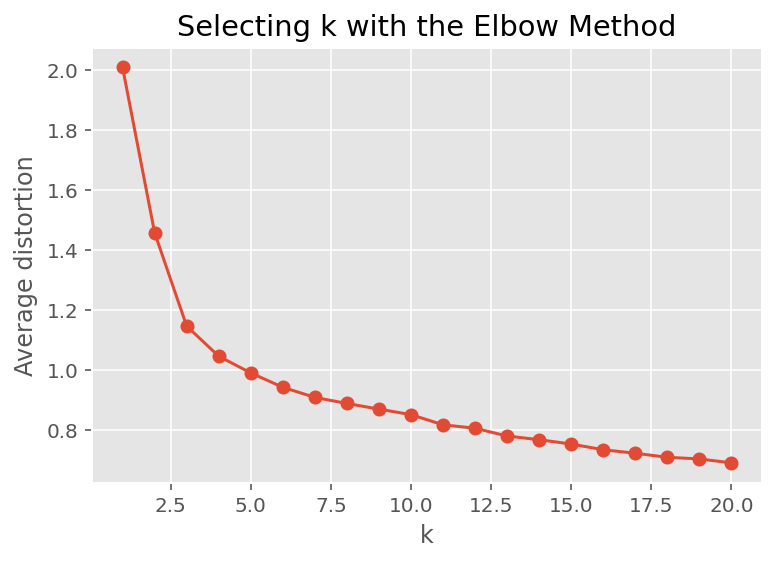

```python
# Finding optimal number of clusters
from scipy.spatial.distance import cdist
clusters = range(1,21)
meanDistortions=[]

for k in clusters:
    model = KMeans(n_clusters=k)
    model.fit(df_scaled)
    prediction = model.predict(df_scaled)
    meanDistortions.append(sum(np.min(cdist(df_scaled, model.cluster_centers_, 'euclidean'), axis=1)) / df_scaled.shape[0])

plt.plot(clusters, meanDistortions, marker = 'o')
plt.xlabel('k')
plt.ylabel('Average distortion')
plt.title('Selecting k with the Elbow Method');
```

**Insights:** From the above elbow method it seems like k = 3 is the distinct elbow point therefore we'll try k=3.

```python
# Set value of k = 3
kmean_model = KMeans(n_clusters=3, n_init=15, random_state=123)
kmean_model.fit(df_scaled)
prediction=kmean_model.predict(df_scaled)
```

```python
# looking at centers in each group
centroids = kmean_model.cluster_centers_
centroid_df = pd.DataFrame(centroids, columns = list(df_scaled))
centroid_df.transpose()
```

|  | 0 | 1 | 2 |
| --- | --- | --- | --- |
| Avg_Credit_Limit | -0.021062 | -0.595796 | 2.831764 |
| Total_Credit_Cards | 0.373690 | -1.059623 | 1.862226 |
| Total_visits_bank | 0.666395 | -0.901518 | -1.105763 |
| Total_visits_online | -0.553672 | 0.322997 | 2.827319 |
| Total_calls_made | -0.553005 | 1.148109 | -0.874330 |

```python
df_att['k_Group'] = prediction
df_att['k_Group'] = df_att['k_Group'].astype('category')
df_scaled['k_Group'] = prediction
df_scaled['k_Group'] = df_scaled['k_Group'].astype('category')
df_att.dtypes
```

```
Avg_Credit_Limit          int64
Total_Credit_Cards        int64
Total_visits_bank         int64
Total_visits_online       int64
Total_calls_made          int64
k_Group                category
dtype: object
```

```python
df_att.head()
```

|  | Avg_Credit_Limit | Total_Credit_Cards | Total_visits_bank | Total_visits_online | Total_calls_made | k_Group |
| --- | --- | --- | --- | --- | --- | --- |
| 0 | 100000 | 2 | 1 | 1 | 0 | 0 |
| 1 | 50000 | 3 | 0 | 10 | 9 | 1 |
| 2 | 50000 | 7 | 1 | 3 | 4 | 0 |
| 3 | 30000 | 5 | 1 | 1 | 4 | 0 |
| 4 | 100000 | 6 | 0 | 12 | 3 | 2 |

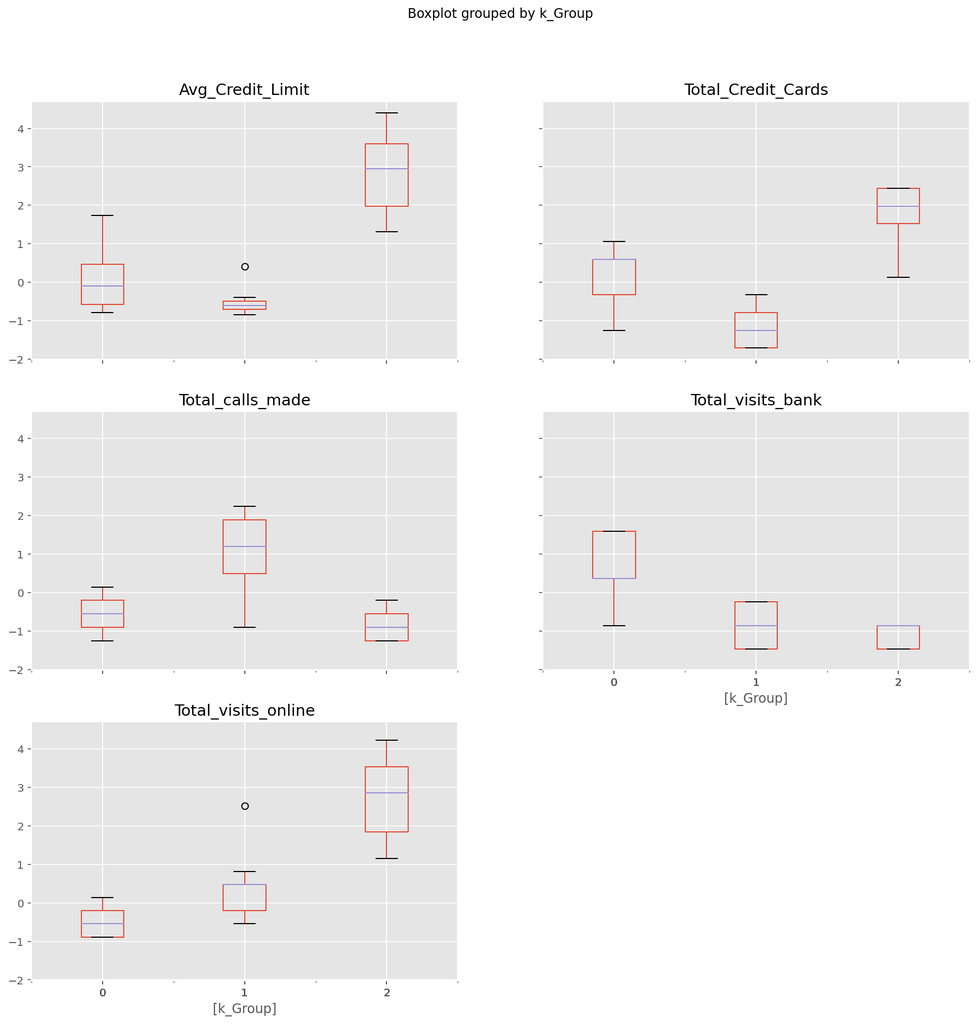

```python
df_scaled.boxplot( by = 'k_Group', layout=(3, 2), figsize=(15,15));
```

```python
df_scaled['k_Group'].value_counts()
```

```
0    386
1    224
2     50
Name: k_Group, dtype: int64
```

## Hierarchical Clustering

```python
# generate the linkage matrix
from scipy.cluster.hierarchy import cophenet, dendrogram, linkage
from scipy.spatial.distance import pdist #Pairwise distribution between data points
Z = linkage(df_scaled, method='ward', metric='euclidean')
c, coph_dists = cophenet(Z, pdist(df_scaled))
c
```

```
0.774233615737438
```

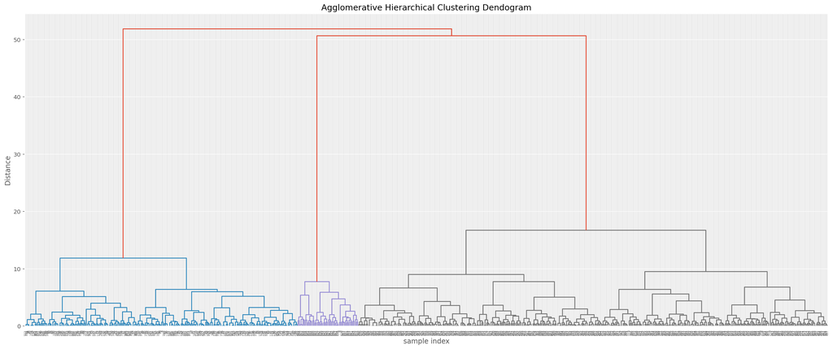

```python
plt.figure(figsize=(25, 10))
plt.title('Agglomerative Hierarchical Clustering Dendogram')
plt.xlabel('sample index')
plt.ylabel('Distance')
dendrogram(Z)
plt.show()
```

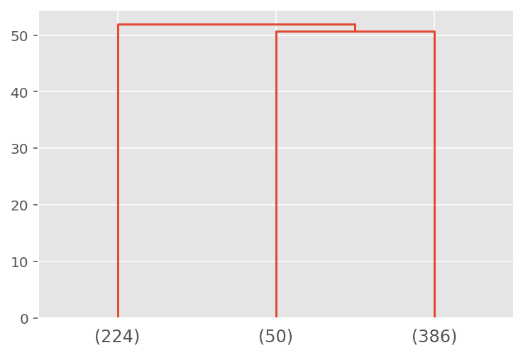

```python
dendrogram(
    Z,
    truncate_mode='lastp',
    p=3
)
plt.show()
```

```python
# using single/minimum distance method
Z2 = linkage(df_scaled, method='single', metric='euclidean')
c2, coph_dists_2 = cophenet(Z2, pdist(df_scaled))
c2
```

```
0.8788676940541079
```

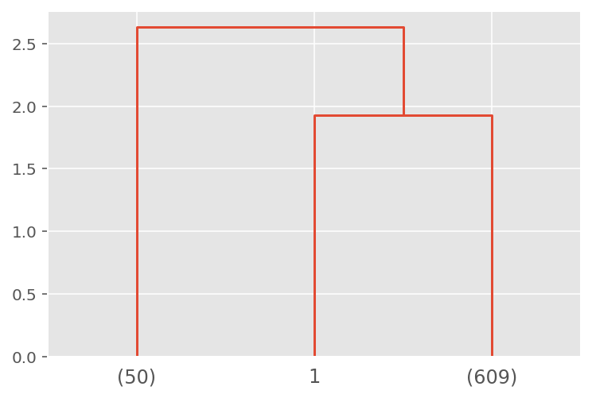

```python
dendrogram(
    Z2,
    truncate_mode='lastp',
    p=3
)
plt.show()
```

```python
# using complete/Maximum distance method
Z = linkage(df_scaled, method='complete', metric='euclidean')
c, coph_dists = cophenet(Z, pdist(df_scaled))
c
```

```
0.8860521900934342
```

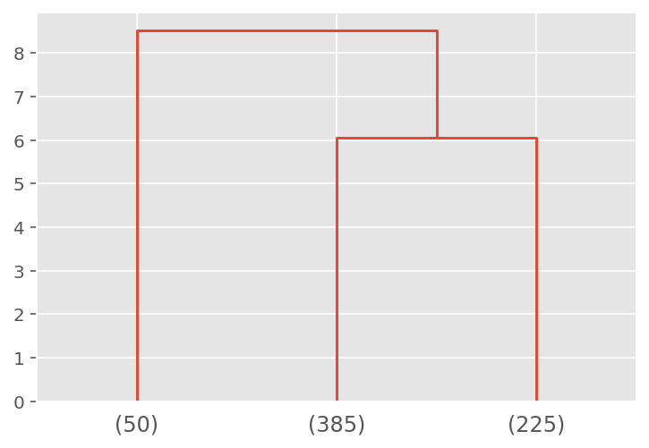

```python
dendrogram(
    Z,
    truncate_mode='lastp',
    p=3
)
plt.show()
```

```python
# using centroid distance method
Z = linkage(df_scaled, method='centroid', metric='euclidean')
c, coph_dists = cophenet(Z, pdist(df_scaled))
c
```

```
0.9134704636213649
```

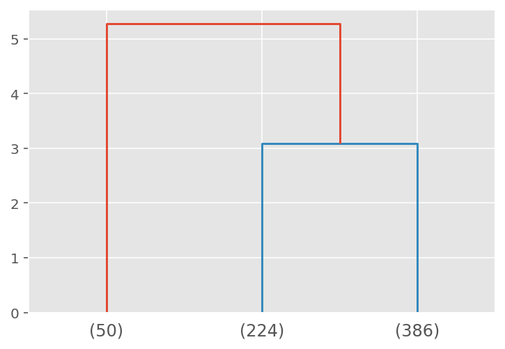

```python
dendrogram(
    Z,
    truncate_mode='lastp',
    p=3
)
plt.show();
```

```python
# using median distance method
Z = linkage(df_scaled, method='median', metric='euclidean')
c, coph_dists = cophenet(Z, pdist(df_scaled))
c
```

```
0.8870097301491704
```

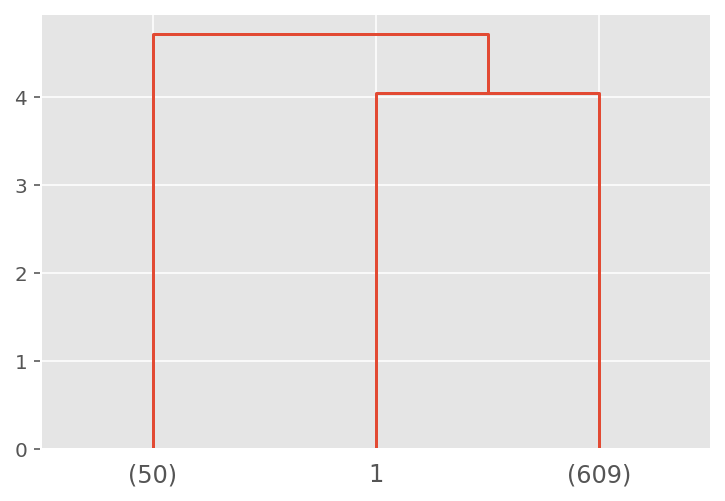

```python
dendrogram(
    Z,
    truncate_mode='lastp',
    p=3
)
plt.show()
```

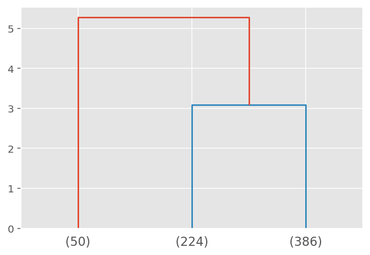

```python
# using centroid distance method gave the highest cphenetic coefficient of 0.913, therefore this will be the linkage method we use
Z = linkage(df_scaled, method='centroid', metric='euclidean')
dendrogram(
    Z,
    truncate_mode='lastp',
    p=3
);
```

```python
max_d = 3
from scipy.cluster.hierarchy import fcluster
h_clusters = fcluster(Z, max_d, criterion='distance')
h_clusters
```

```
array([3, 2, 3, 3, 1, 2, 1, 2, 2, 2, 2, 2, 2, 2, 2, 2, 2, 2, 2, 2, 2, 2,
       2, 2, 2, 2, 2, 2, 2, 2, 2, 2, 2, 2, 2, 2, 2, 2, 2, 2, 2, 2, 2, 2,
       2, 2, 2, 2, 2, 2, 2, 2, 2, 2, 2, 2, 2, 2, 2, 2, 2, 2, 2, 2, 2, 2,
       2, 2, 2, 2, 2, 2, 2, 2, 2, 2, 2, 2, 2, 2, 2, 2, 2, 2, 2, 2, 2, 2,
       2, 2, 2, 2, 2, 2, 2, 2, 2, 2, 2, 2, 2, 2, 2, 2, 2, 2, 2, 2, 2, 2,
       2, 2, 2, 2, 2, 2, 2, 2, 2, 2, 2, 2, 2, 2, 2, 2, 2, 2, 2, 2, 2, 2,
       2, 2, 2, 2, 2, 2, 2, 2, 2, 2, 2, 2, 2, 2, 2, 2, 2, 2, 2, 2, 2, 2,
       2, 2, 2, 2, 2, 2, 2, 2, 2, 2, 2, 2, 2, 2, 2, 2, 2, 2, 2, 2, 2, 2,
       2, 2, 2, 2, 2, 2, 2, 2, 2, 2, 2, 2, 2, 2, 2, 2, 2, 2, 2, 2, 2, 2,
       2, 2, 2, 2, 2, 2, 2, 2, 2, 2, 2, 2, 2, 2, 2, 2, 2, 2, 2, 2, 2, 2,
       2, 2, 2, 2, 2, 2, 2, 2, 3, 3, 3, 3, 3, 3, 3, 3, 3, 3, 3, 3, 3, 3,
       3, 3, 3, 3, 3, 3, 3, 3, 3, 3, 3, 3, 3, 3, 3, 3, 3, 3, 3, 3, 3, 3,
       3, 3, 3, 3, 3, 3, 3, 3, 3, 3, 3, 3, 3, 3, 3, 3, 3, 3, 3, 3, 3, 3,
       3, 3, 3, 3, 3, 3, 3, 3, 3, 3, 3, 3, 3, 3, 3, 3, 3, 3, 3, 3, 3, 3,
       3, 3, 3, 3, 3, 2, 3, 3, 3, 3, 3, 3, 3, 3, 3, 3, 3, 3, 3, 3, 3, 3,
```

[output cut: 16 more lines]

```python
df_scaled['h_Group'] = h_clusters
df_scaled['h_Group'] = df_scaled['h_Group'].astype('category')
df_att['h_Group'] = h_clusters
df_att['h_Group'] = df_att['h_Group'].astype('category')
df_att.head()
```

|  | Avg_Credit_Limit | Total_Credit_Cards | Total_visits_bank | Total_visits_online | Total_calls_made | k_Group | h_Group |
| --- | --- | --- | --- | --- | --- | --- | --- |
| 0 | 100000 | 2 | 1 | 1 | 0 | 0 | 3 |
| 1 | 50000 | 3 | 0 | 10 | 9 | 1 | 2 |
| 2 | 50000 | 7 | 1 | 3 | 4 | 0 | 3 |
| 3 | 30000 | 5 | 1 | 1 | 4 | 0 | 3 |
| 4 | 100000 | 6 | 0 | 12 | 3 | 2 | 1 |

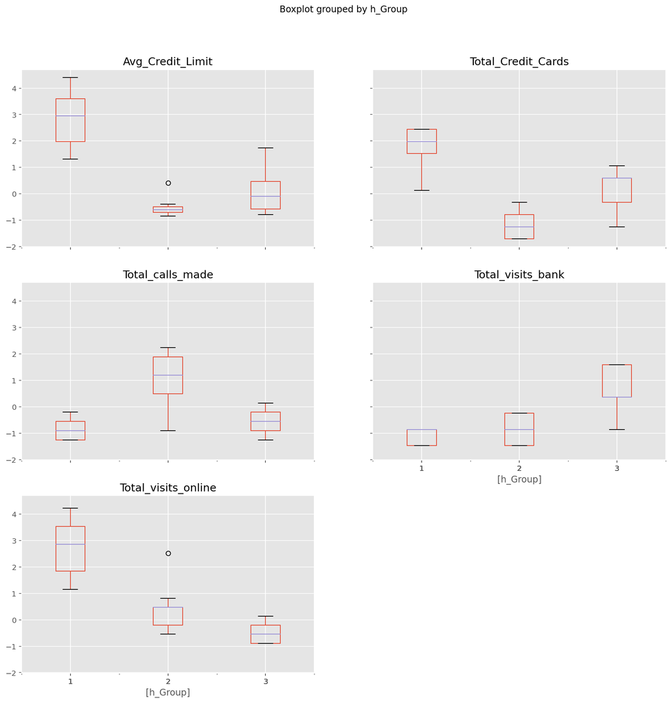

```python
df_scaled.boxplot( by = 'h_Group', layout=(3, 2), figsize=(15,15));
```

### Final dendogram with 'centroid' linkage

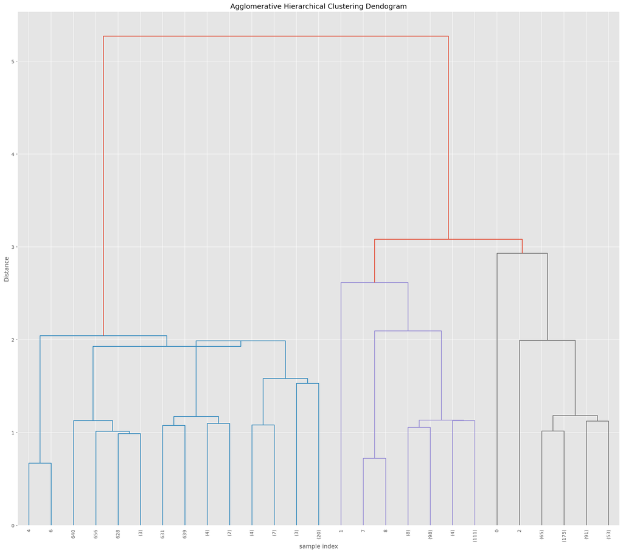

```python
plt.figure(figsize=(18, 16))
plt.title('Agglomerative Hierarchical Clustering Dendogram')
plt.xlabel('sample index')
plt.ylabel('Distance')
Z = linkage(df_scaled, method='centroid', metric='euclidean')
dendrogram(Z, leaf_rotation=90.0, p=5, color_threshold=3, truncate_mode='level')
plt.tight_layout()
```

### Silhouette Score

```python
#Calclulate Avg Silhouette Score from final dendogram
from sklearn.metrics import silhouette_score
hierarchical_score = silhouette_score(df_scaled, df_scaled['k_Group'])
hierarchical_score
```

```
0.5621118591626343
```

```python
km_score = silhouette_score(df_scaled, df_scaled['h_Group'], metric='euclidean')
km_score
```

```
0.5621118591626343
```

## Conclusion

Knowing that we derived to 3 segments of customers, and these segments mirrored each other as outlined above betweeen the two methods, we'll outline how these segments were formed using the k_Group segmentation only, since the same can be said for the equivalent h_Group segments.

Specifically, you can see that k_Group 0 had the highest Average number of Visits to the Bank compared to the other two segments while also having the lowest online visits. While k_Group 1 segmented the customers with highest total calls made and lowest total credit cards in this group. Finally, the k_Group 2 was segmented by highest Average Credit Limit, highest Total number of Credit Cards as well as the most average Total visits online.

Looking at the segmentation from this analysis, it's clear that customers that fall into the k_Group 2 tend to have hiher Credit Limits and larger number of credit cards, but interestingly enough they also tend to rely on online banking more than the other groups. Therefore, making sure to have this group marketed any potential website or app products that could help them streamline their banking process would likely be appreciated by this group. Meanwhile, k_Group 1 tends to make the most phone calls yet has the lowest number of credit cards, which could lead AllLife to possibly target this group via direct phone calls to push any new products or services they may wish to promote to this group. Finally, k_Group 0 are the customer segments that seem to prefer showing up to the bank in person and use the online services the least. This group might not be the best segment to target online, yet may be the type of individuals who respond well to physical mail offers possibly flag these customers to have the tellers mention any promotion next time they come into the bank.